# Tornado and Flood bring most damage to our health and wealth

## Synopsys

In this report we aim to answer two questions: - Across the United States, which types of events are most harmful with respect to population health? - Across the United States, which types of events have the greatest economic consequences? To get answer we obtain data from the U.S. National Oceanic and Atmospheric Administration’s (NOAA) storm database, which include characteristics of major storms and weather events in the United States, including when and where they occur, as well as estimates of any fatalities, injuries, and property damage. Data are collected from 1950 to November 2011. From data analysis we found that Tornado is the most harmfull events, and Flood has the biggest economical consequencies in total, although Drought brings more damage to crop.

## Data processing

First we download data from https://d396qusza40orc.cloudfront.net/repdata%2Fdata%2FStormData.csv.bz2.

```r
download.file("https://d396qusza40orc.cloudfront.net/repdata%2Fdata%2FStormData.csv.bz2", destfile="StormData.bz2", method="curl")
```

Then we read in the data from csv file in bz2 archive and get some information about data structure.

```r
dt <- read.csv(".\\StormData\\StormData.csv")
str(dt)
```

```
## 'data.frame':    902297 obs. of  37 variables:
##  $ STATE__   : num  1 1 1 1 1 1 1 1 1 1 ...
##  $ BGN_DATE  : Factor w/ 16335 levels "1/1/1966 0:00:00",..: 6523 6523 4242 11116 2224 2224 2260 383 3980 3980 ...
##  $ BGN_TIME  : Factor w/ 3608 levels "00:00:00 AM",..: 272 287 2705 1683 2584 3186 242 1683 3186 3186 ...
##  $ TIME_ZONE : Factor w/ 22 levels "ADT","AKS","AST",..: 7 7 7 7 7 7 7 7 7 7 ...
##  $ COUNTY    : num  97 3 57 89 43 77 9 123 125 57 ...
##  $ COUNTYNAME: Factor w/ 29601 levels "","5NM E OF MACKINAC BRIDGE TO PRESQUE ISLE LT MI",..: 13513 1873 4598 10592 4372 10094 1973 23873 24418 4598 ...
##  $ STATE     : Factor w/ 72 levels "AK","AL","AM",..: 2 2 2 2 2 2 2 2 2 2 ...
##  $ EVTYPE    : Factor w/ 985 levels "   HIGH SURF ADVISORY",..: 834 834 834 834 834 834 834 834 834 834 ...
##  $ BGN_RANGE : num  0 0 0 0 0 0 0 0 0 0 ...
##  $ BGN_AZI   : Factor w/ 35 levels "","  N"," NW",..: 1 1 1 1 1 1 1 1 1 1 ...
##  $ BGN_LOCATI: Factor w/ 54429 levels "","- 1 N Albion",..: 1 1 1 1 1 1 1 1 1 1 ...
##  $ END_DATE  : Factor w/ 6663 levels "","1/1/1993 0:00:00",..: 1 1 1 1 1 1 1 1 1 1 ...
##  $ END_TIME  : Factor w/ 3647 levels ""," 0900CST",..: 1 1 1 1 1 1 1 1 1 1 ...
##  $ COUNTY_END: num  0 0 0 0 0 0 0 0 0 0 ...
```

[output cut: 23 more lines]

```r
head(dt)
```

```
##   STATE__           BGN_DATE BGN_TIME TIME_ZONE COUNTY COUNTYNAME STATE
## 1       1  4/18/1950 0:00:00     0130       CST     97     MOBILE    AL
## 2       1  4/18/1950 0:00:00     0145       CST      3    BALDWIN    AL
## 3       1  2/20/1951 0:00:00     1600       CST     57    FAYETTE    AL
## 4       1   6/8/1951 0:00:00     0900       CST     89    MADISON    AL
## 5       1 11/15/1951 0:00:00     1500       CST     43    CULLMAN    AL
## 6       1 11/15/1951 0:00:00     2000       CST     77 LAUDERDALE    AL
##    EVTYPE BGN_RANGE BGN_AZI BGN_LOCATI END_DATE END_TIME COUNTY_END
## 1 TORNADO         0                                               0
## 2 TORNADO         0                                               0
## 3 TORNADO         0                                               0
## 4 TORNADO         0                                               0
## 5 TORNADO         0                                               0
## 6 TORNADO         0                                               0
##   COUNTYENDN END_RANGE END_AZI END_LOCATI LENGTH WIDTH F MAG FATALITIES
```

[output cut: 20 more lines]

Select only variables that we are interested in (connected with population health and economic consequencies)

```r
library(dplyr)
dt <- select(dt, REFNUM, BGN_DATE, EVTYPE, FATALITIES, INJURIES, PROPDMG, PROPDMGEXP, CROPDMG, CROPDMGEXP)
```

Let’s look at values that we have for variables PROPDMGEXP and CROPDMGEXP

```r
levels(dt$PROPDMGEXP)
```

```
##  [1] ""  "-" "?" "+" "0" "1" "2" "3" "4" "5" "6" "7" "8" "B" "h" "H" "K"
## [18] "m" "M"
```

```r
levels(dt$CROPDMGEXP)
```

```
## [1] ""  "?" "0" "2" "B" "k" "K" "m" "M"
```

As these columns stand for units of corresponding variables it’s obvious (and can be read form description file), what values ‘h’,‘m’,‘b’ and ‘k’ stand for. Other values don’t make sense, so let’s look at how many rows we have with such values and what are the years of corresponding records.

```r
library(lubridate)
dt<- mutate(dt, Year = year(as.Date(as.character(BGN_DATE),"%m/%d/%Y %H:%M:%S")))
strangeUnits <- filter(dt, PROPDMGEXP %in% c("-","?","+","0","1","2","3","4","5","6","7","8") | CROPDMGEXP %in% c("?","0","2"))
nrow(strangeUnits)
```

```
## [1] 341
```

```r
table(strangeUnits$Year)
```

```
##
## 1993 1994 1995 2011
##    8   42  290    1
```

As we see, there aren’t many of them (comparing to the size of dataset) and almost all of the cases correspond to 1994-1995 years (maybe system of records wasn’t very precise in these years). So our decision will be to throw away these data.

```r
dt <- filter(dt, !(PROPDMGEXP %in% c("-","?","+","0","1","2","3","4","5","6","7","8") | CROPDMGEXP %in% c("?","0","2")))
```

Now we add columns with corrected sums.

```r
dt<- dt %>% mutate(PROPDMGEXP = tolower(PROPDMGEXP), CROPDMGEXP = tolower(CROPDMGEXP)) %>%
            mutate(PropDmg = ifelse(PROPDMGEXP=='h', PROPDMG*100,PROPDMG)) %>%
            mutate(CropDmg = ifelse(CROPDMGEXP=='h', CROPDMG*100,CROPDMG)) %>%
            mutate(PropDmg = ifelse(PROPDMGEXP=='k', PROPDMG*1000,PropDmg)) %>%
            mutate(CropDmg = ifelse(CROPDMGEXP=='k', CROPDMG*1000,CropDmg)) %>%
            mutate(PropDmg = ifelse(PROPDMGEXP=='m', PROPDMG*1000000,PropDmg)) %>%
            mutate(CropDmg = ifelse(CROPDMGEXP=='m', CROPDMG*1000000,CropDmg)) %>%
            mutate(PropDmg = ifelse(PROPDMGEXP=='b', PROPDMG*1000000000,PropDmg)) %>%
            mutate(CropDmg = ifelse(CROPDMGEXP=='b', CROPDMG*1000000000,CropDmg)) %>%
            mutate(TotalDmg = PropDmg+CropDmg) %>%
            mutate(TotalInj = FATALITIES+INJURIES)
```

Then we aggregate data by event type.

```r
dtagg <- aggregate(dt[,c('PropDmg','CropDmg','TotalDmg','FATALITIES','INJURIES','TotalInj')], by=list(dt$EVTYPE), FUN=sum)
```

## Results

The first question we are interested in is “Across the United States, which types of events are most harmful with respect to population health?” In order to answer let’s first remove events with zero total harmness.

```r
dtHarm <- filter(dtagg, TotalInj > 0)
dim(dtHarm)
```

```
## [1] 219   7
```

We still have a lot of data, so let’s look at top ten most harmfull types.

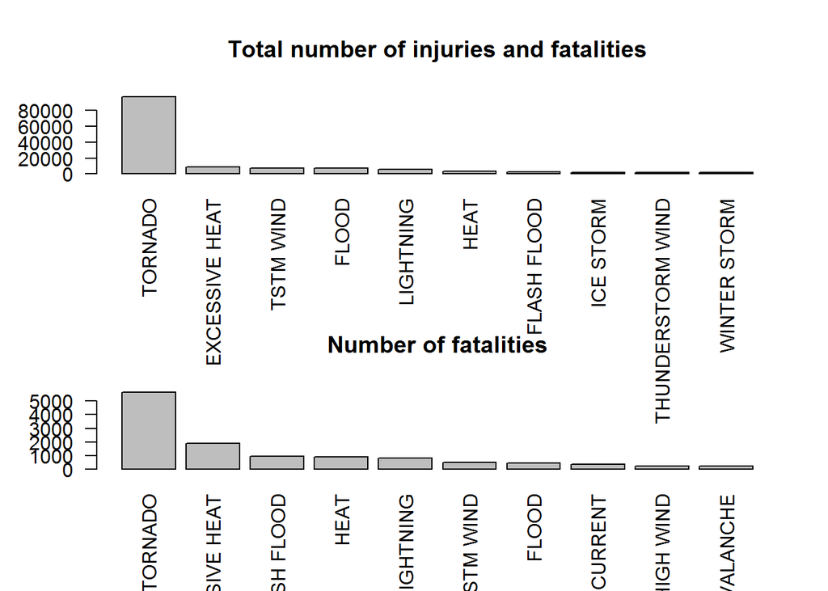

```r
par(mfrow=c(2,1))
dtHarmTotal <- dtHarm %>% arrange(desc(TotalInj)) %>% slice(1:10)
barplot(dtHarmTotal$TotalInj, names.arg=dtHarmTotal$Group.1, las=2, main="Total number of injuries and fatalities")

dtHarmFat <- dtHarm %>% arrange(desc(FATALITIES)) %>% slice(1:10)
barplot(dtHarmFat$FATALITIES, names.arg=dtHarmFat$Group.1, las=2, main="Number of fatalities")
```

From plots we see that most harmful events are Tornado and Excessive heat both for counting fatalities or total injuries.

Now let’s consider another question “Across the United States, which types of events have the greatest economic consequences?”.

So let’s look at top ten most damagefull types.

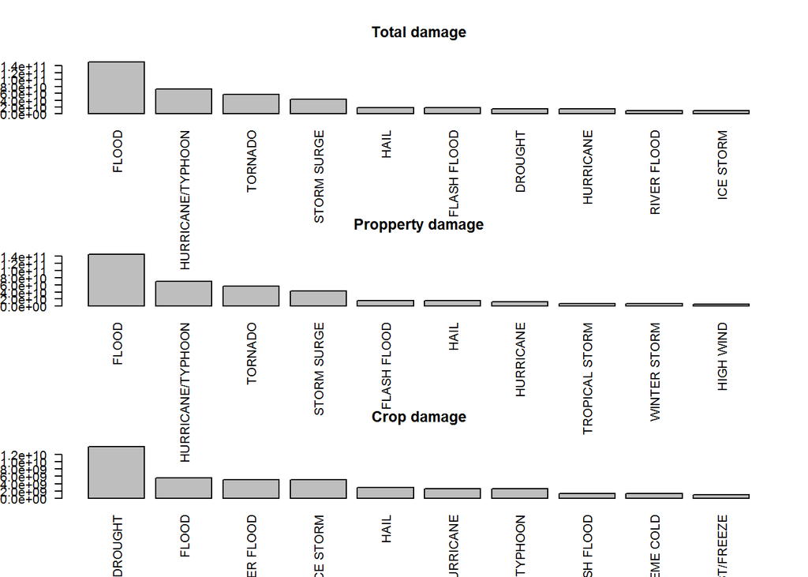

```r
par(mfrow=c(3,1))
dtDmgTotal <- dtagg %>% arrange(desc(TotalDmg)) %>% slice(1:10)
barplot(dtDmgTotal$TotalDmg, names.arg=dtDmgTotal$Group.1, las=2, main="Total damage")

dtDmgProp <- dtagg %>% arrange(desc(PropDmg)) %>% slice(1:10)
barplot(dtDmgProp$PropDmg, names.arg=dtDmgProp$Group.1, las=2, main="Propperty damage")

dtDmgCrop <- dtagg %>% arrange(desc(CropDmg)) %>% slice(1:10)
barplot(dtDmgCrop$CropDmg, names.arg=dtDmgCrop$Group.1, las=2, main="Crop damage")
```

Now we see that considering total damage or property damage Flood is the most harmful event, but for crop damage we see it at the second place with Drought at the first, which quite makes sense.